# Biostat 203B Homework 4 Solutions

Due Mar 12 @ 11:59PM

Analissa Avila

Load database libraries and the tidyverse frontend:

```r
library(tidyverse)
library(lubridate)
library(miceRanger)
```

## Q1. Missing data

Through the Shiny app developed in HW3, we observe abundant missing values in the MIMIC-IV ICU cohort we created. In this question, we use multiple imputation to obtain a dataset without missing values.

0. Read following tutorials on the R package miceRanger for imputation: https://github.com/farrellday/miceRanger, https://cran.r-project.org/web/packages/miceRanger/vignettes/miceAlgorithm.html.

   A more thorough book treatment of the practical imputation strategies is the book [*Flexible Imputation of Missing Data*](https://stefvanbuuren.name/fimd/) by Stef van Buuren.

#### Solution - read tutorials

Done.

1. Explain the jargon MCAR, MAR, and MNAR.

#### Solution - explaining MCAR, MAR, and MNAR

MCAR, MAR, and MNAR refer to the three missing data mechanisms. A missing data mechanism is the process that determines the probabilities of data being missing.

MCAR stands for missing completely at random. This occurs when the probability of being missing is the same for all cases. Essentially the cause of the missingness is unrelated to the data. Although MCAR is the most ideal missing data mechanism, it is often unrealistic.

MAR stands for missing at random. This occurs when the probability of being missing is the same only within groups defined by the observed data. That is to say, if there is a fully observed variable and a variable with missing data, the probability of response depends on the fully observed variable only. MAR is more realistic than MCAR.

MNAR stands for missing not at random. This occurs when the probability of being missing is varied for reasons that are unknown. That is to say, if there is a fully observed variable and a variable with missing data, the probability of response depends on the variable with missing data and possibly on the fully observed variable as well.

2. Explain in a couple of sentences how the Multiple Imputation by Chained Equations (MICE) work.

#### Solution - explaining how MICE works

Multiple Imputation by Chained Equations is a procedure that uses predictive models to iteratively fill in the missing data in a dataset. During each iteration, each specified variable in the dataset is imputed using the other variables. In the end, a complete dataset is returned, however, you can choose to create multiple complete datasets that are then pooled to create a final dataset.

3. Perform a data quality check of the ICU stays data. Discard variables with substantial missingness, say >5000 `NA`s. Replace apparent data entry errors by `NA`s.

#### Solution - data checking and cleaning

Read in icu cohort data

```r
#read in icu cohort data from HW3
icu_cohort <- readRDS("icu_cohort.rds")
```

Discard variables with substantial missingness (>5,000 `NA`s).

- Three of the demographic, lab measurement, and vitals variables are missing more than 5,000 values: `lactate` (19,843 missing), `arterial_blood_pressure_systolic` (29,019 missing), and `arterial_blood_pressure_mean` (28,897 missing).
- The variables `edregtime`, `edouttime`, `dod`, `deathtime`, and `admit_to_death` are also missing over 5,000 values and will be removed.

```r
#Identify variables with > 5000 NAs
colSums(is.na(icu_cohort))[colSums(is.na(icu_cohort)) > 5000]
```

```
##                        edregtime                        edouttime
##                            18462                            18462
##                        deathtime                              dod
##                            42624                            50048
##                          lactate arterial_blood_pressure_systolic
##                            19843                            29019
##     arterial_blood_pressure_mean                   admit_to_death
##                            28897                            42624
```

```r
#Remove 8 identified variables
icu_cohort <- icu_cohort %>%
  select(-c(lactate, arterial_blood_pressure_systolic,
            arterial_blood_pressure_mean, edregtime,
            edouttime, dod, deathtime, admit_to_death))
```

Replace apparent data entry errors by `NA`s.

We will consider values outside of the 1% to 99% percentile range to be data entry errors.  
This range was chosen because, by looking at the Shiny app/researching normal ranges, many outlying values per the 1.5IQR rule are still plausible. We should consult with the data provider to determine what constitutes as an extreme value for each lab measurement and vital.  
If the identified data point is out of this range, then replace it with `NA`.

**Note:** Unknown ethnicity is retained as its own category rather than considering it missing. It may be of interest to analyze the results of patients with “unknown” ethnicity. For example, if patients with unknown ethnicity have higher odds of death in 30 days, it could be hypothesized that patient who are more ill are unable or unwilling to provide race/ethnicity information.

**Lab Measurements**

```r
#bicarbonate
bicarb.low <- quantile(icu_cohort$bicarbonate, .01, na.rm = TRUE)
bicarb.high <- quantile(icu_cohort$bicarbonate, .99, na.rm = TRUE)

icu_cohort$bicarbonate <- ifelse(icu_cohort$bicarbonate < bicarb.low |
                                   icu_cohort$bicarbonate > bicarb.high,
                                 NA, icu_cohort$bicarbonate)


#calcium
calcium.low <- quantile(icu_cohort$calcium, .01, na.rm = TRUE)
calcium.high <- quantile(icu_cohort$calcium, .99, na.rm = TRUE)

icu_cohort$calcium <- ifelse(icu_cohort$calcium < calcium.low |
                               icu_cohort$calcium > calcium.high,
                             NA, icu_cohort$calcium)


#chloride
chloride.low <- quantile(icu_cohort$chloride, .01, na.rm = TRUE)
chloride.high <- quantile(icu_cohort$chloride, .99, na.rm = TRUE)

icu_cohort$chloride <- ifelse(icu_cohort$chloride < chloride.low |
                                icu_cohort$chloride > chloride.high,
                              NA, icu_cohort$chloride)


#creatinine
creat.low <- quantile(icu_cohort$creatinine, .01, na.rm = TRUE)
creat.high <- quantile(icu_cohort$creatinine, .99, na.rm = TRUE)

icu_cohort$creatinine <- ifelse(icu_cohort$creatinine < creat.low |
                                  icu_cohort$creatinine > creat.high,
                                NA, icu_cohort$creatinine)

#glucose
glucose.low <- quantile(icu_cohort$glucose, .01, na.rm = TRUE)
glucose.high <- quantile(icu_cohort$glucose, .99, na.rm = TRUE)

icu_cohort$glucose <- ifelse(icu_cohort$glucose < glucose.low |
                               icu_cohort$glucose > glucose.high,
                                NA, icu_cohort$glucose)


#magnesium
magn.low <- quantile(icu_cohort$magnesium, .01, na.rm = TRUE)
magn.high <- quantile(icu_cohort$magnesium, .99, na.rm = TRUE)

icu_cohort$magnesium <- ifelse(icu_cohort$magnesium < magn.low |
                                 icu_cohort$magnesium > magn.high,
                                NA, icu_cohort$magnesium)

#potassium
potas.low <- quantile(icu_cohort$potassium, .01, na.rm = TRUE)
potas.high <- quantile(icu_cohort$potassium, .99, na.rm = TRUE)

icu_cohort$potassium <- ifelse(icu_cohort$potassium < potas.low |
                                 icu_cohort$potassium > potas.high,
                                NA, icu_cohort$potassium)


#sodium
sodium.low <- quantile(icu_cohort$sodium, .01, na.rm = TRUE)
sodium.high <- quantile(icu_cohort$sodium, .99, na.rm = TRUE)

icu_cohort$sodium <- ifelse(icu_cohort$sodium < sodium.low |
                                 icu_cohort$sodium > sodium.high,
                                NA, icu_cohort$sodium)


#hematocrit
hema.low <- quantile(icu_cohort$hematocrit, .01, na.rm = TRUE)
hema.high <- quantile(icu_cohort$hematocrit, .99, na.rm = TRUE)

icu_cohort$hematocrit <- ifelse(icu_cohort$hematocrit < hema.low |
                                 icu_cohort$hematocrit > hema.high,
                                NA, icu_cohort$hematocrit)


#wbc
wbc.low <- quantile(icu_cohort$wbc, .01, na.rm = TRUE)
wbc.high <- quantile(icu_cohort$wbc, .99, na.rm = TRUE)

icu_cohort$wbc <- ifelse(icu_cohort$wbc < wbc.low |
                           icu_cohort$wbc > wbc.high,
                                NA, icu_cohort$wbc)
```

**Vitals**

```r
#heart rate
hr.low <- quantile(icu_cohort$heart_rate, .01, na.rm = TRUE)
hr.high <- quantile(icu_cohort$heart_rate, .99, na.rm = TRUE)

icu_cohort$heart_rate <- ifelse(icu_cohort$heart_rate < hr.low |
                                  icu_cohort$heart_rate > hr.high,
                                NA, icu_cohort$heart_rate)


#systolic NI blood pressure
NIbp.sys.low <- quantile(icu_cohort$non_invasive_blood_pressure_systolic,
                         .01, na.rm = TRUE)
NIbp.sys.high <- quantile(icu_cohort$non_invasive_blood_pressure_systolic,
                          .99, na.rm = TRUE)

icu_cohort$non_invasive_blood_pressure_systolic <-
  ifelse(icu_cohort$non_invasive_blood_pressure_systolic < NIbp.sys.low |
           icu_cohort$non_invasive_blood_pressure_systolic > NIbp.sys.high,
         NA, icu_cohort$non_invasive_blood_pressure_systolic)


#mean NI blood pressure
NIbp.mean.low <- quantile(icu_cohort$non_invasive_blood_pressure_mean,
                          .01, na.rm = TRUE)
NIbp.mean.high <- quantile(icu_cohort$non_invasive_blood_pressure_mean,
                           .99, na.rm = TRUE)

icu_cohort$non_invasive_blood_pressure_mean <-
  ifelse(icu_cohort$non_invasive_blood_pressure_mean < NIbp.mean.low |
           icu_cohort$non_invasive_blood_pressure_mean > NIbp.mean.high,
         NA, icu_cohort$non_invasive_blood_pressure_mean)


#respiratory rate
rr.low <- quantile(icu_cohort$respiratory_rate, .01, na.rm = TRUE)
rr.high <- quantile(icu_cohort$respiratory_rate, .99, na.rm = TRUE)

icu_cohort$respiratory_rate <- ifelse(icu_cohort$respiratory_rate < rr.low |
                                        icu_cohort$respiratory_rate > rr.high,
                                      NA, icu_cohort$respiratory_rate)


#temperature in fahrenheit
temp.low <- quantile(icu_cohort$temperature_fahrenheit, .01, na.rm = TRUE)
temp.high <- quantile(icu_cohort$temperature_fahrenheit, .99, na.rm = TRUE)

icu_cohort$temperature_fahrenheit <-
  ifelse(icu_cohort$temperature_fahrenheit < temp.low |
           icu_cohort$temperature_fahrenheit > temp.high,
         NA, icu_cohort$temperature_fahrenheit)
```

Now that more `NA`s have been created, check again for variables with > 5000 missing values.  
All remaining variables are missing less than 5000 values.

```r
#Identify variables with > 5000 NAs
colSums(is.na(icu_cohort))[colSums(is.na(icu_cohort)) > 5000]
```

```
## named numeric(0)
```

In order for the imputation process to run faster, subset the dataset by removing variables that are non-informative or not relevant to our predictive model in Question 2.

- Remove ID variables (`subject_id`, `hadm_id`, `stay_id`) since they are non-informative in regards to prediction.
- Remove `first_careunit`, `last_careunit`, `admission_type`, `admission_location`, and `discharge_location`. These variables are not relevant to our predictive model.
- Remove `intime`, `outtime`, `admittime`, and `dischtime` as they are likely non-informative in regards to prediction.
- Remove `anchor_year` and `anchor_year_group` since they are likely non-informative in regards to prediction.
- Remove `anchor_age` but keep `age_at_admit` which is more informative.
- Remove `language` and `insurance` as these demographic variables are not relevant to our predictive model.
- Remove `died` (death indicator) and `hospital_expire_flag` since the mortality outcome of interest is death in 30 days.

```r
icu_cohort_sub <- icu_cohort %>%
  select(-c(subject_id, hadm_id, stay_id,
            first_careunit, last_careunit, admission_type,
            admission_location, discharge_location,
            intime, outtime, admittime, dischtime,
            anchor_year, anchor_year_group, anchor_age,
            insurance, language, died, hospital_expire_flag))
```

4. Impute missing values by `miceRanger` (request $m=3$ datasets). This step is very computational intensive. Make sure to save the imputation results as a file.

#### Solution - imputation

```r
if(!file.exists("miceObj_icu_cohort.RData")){
  miceObj <- miceRanger(
    icu_cohort_sub,
    m = 3,
    returnModels = FALSE,
    verbose = FALSE,
    max.depth = 10
    )
  save(miceObj, file = "miceObj_icu_cohort.RData")
}

load("miceObj_icu_cohort.RData")

print(miceObj)
```

```
## Class:          miceDefs
## Datasets:       3
## Iterations:     5
## Total Seconds:  3760
## Imputed Cols:   16
## Estimated Time per Additional Iteration is 752 Seconds
## Estimated Time per Additional Dataset is 1253 Seconds
##
## For additional metrics, see the different plotting functions.
```

5. Make imputation diagnostic plots and explain what they mean.

#### Solution - diagnostic plots

**Distribution of imputed values**  
Numeric variables:

- The red line is the density of the original, non-missing data. The smaller, black lines are the density of the imputed values in each of the datasets.
- For each of the numeric variables, the densities of the imputed values are very close to those of the non-missing data. The densities of the imputed blood pressure variables deviate the most from the original non-missing data.

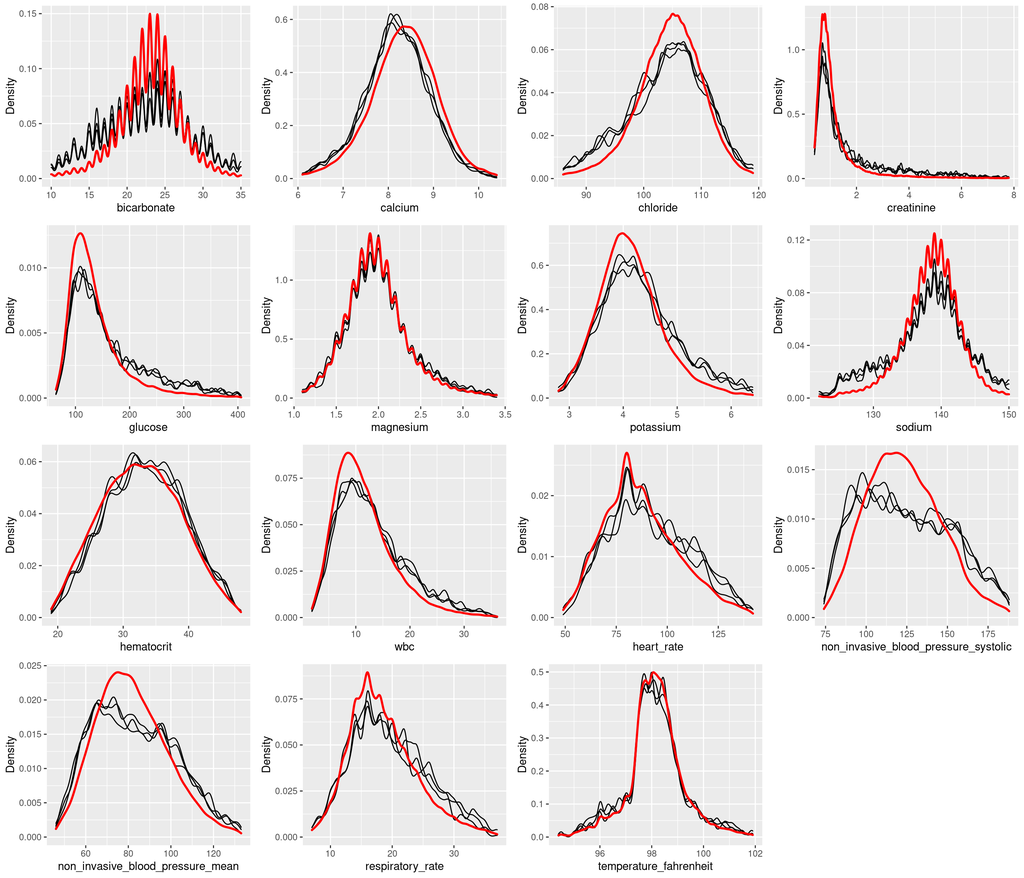

```r
plotDistributions(miceObj, vars = 'allNumeric')
```

Categorical variable:

- The bar graph gives the distribution of the original, non-missing data. The dots give the distribution of the imputed values in each dataset.
- The distribution of the imputed values is very similar to that of the original, non-missing data.

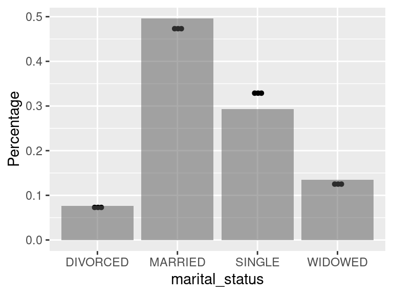

```r
plotDistributions(miceObj, vars = 'allCategorical')
```

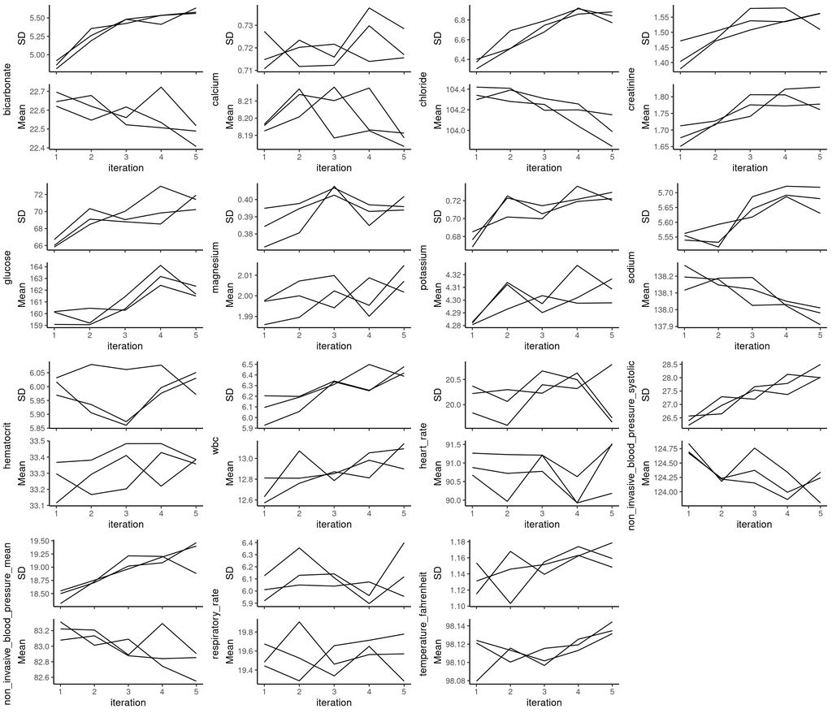

```r
plotVarConvergence(miceObj, vars = 'allNumeric')
```

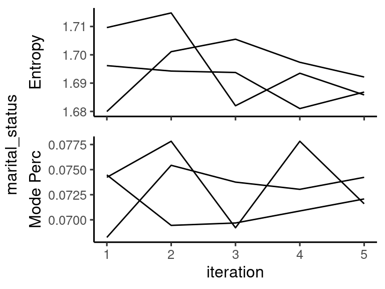

```r
plotVarConvergence(miceObj, vars = 'allCategorical')
```

**Variable importance**  
Plot the variable importance for each imputed variable. The top axis contains the variable that was used to impute the variable on the left axis. The plot shows that age at admission was used to impute marital status, heart rate was used to impute respiratory rate and temperature, etc.

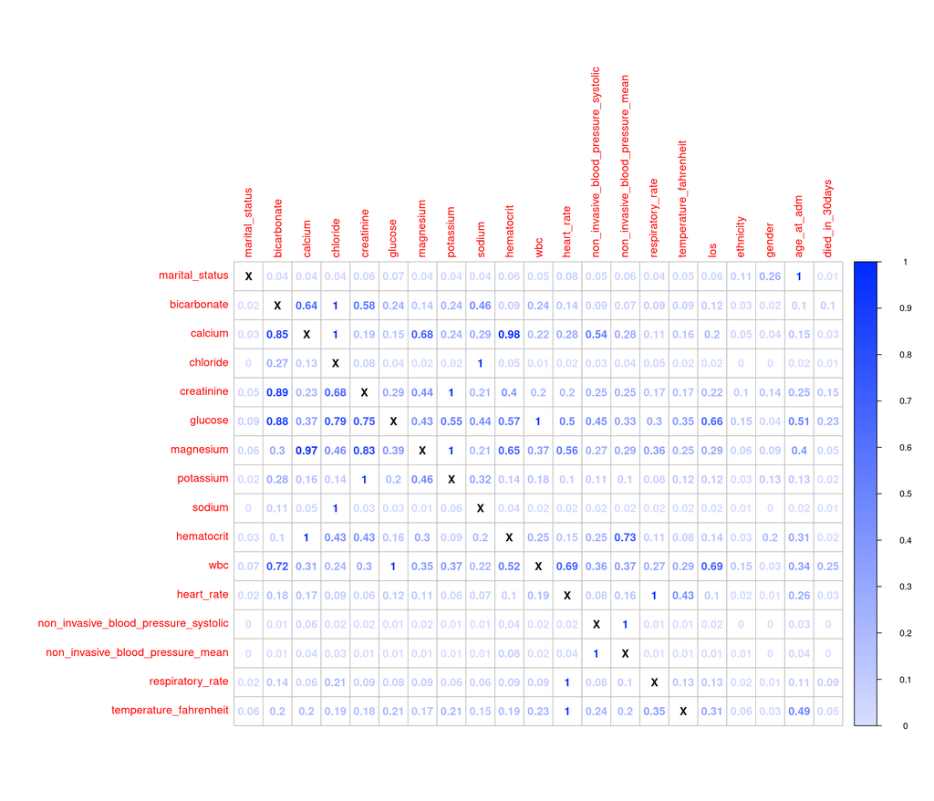

```r
plotVarImportance(miceObj)
```

**Imputed variance between datasets**  
We can get a feel for the variance experienced for each imputed value between the datasets using the plot below. For marital status (categorical), we see that the distribution of the number of unique imputed values is nearly the same as the theoretical distribution of the unique levels, given they were drawn randomly. For the numeric variables, we see a range of about 70-80% of samples with a SD below the population SD.

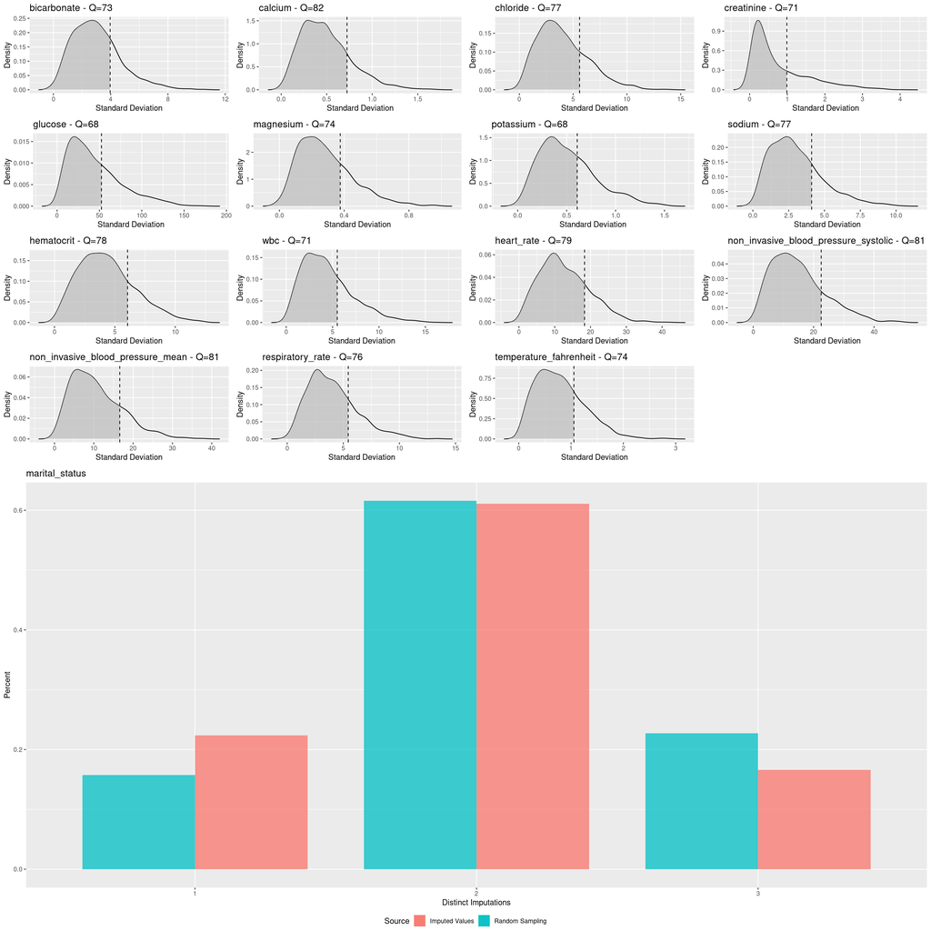

```r
plotImputationVariance(miceObj, ncol = 1)
```

6. Obtain a complete dataset by averaging the 3 imputed datasets.

#### Solution - complete dataset

Numeric variables: get average value of each variable across the 3 datasets, by subject

```r
#3 imputed datasets
dataList <- completeData(miceObj)
datImp1 <- dataList[[1]]
datImp2 <- dataList[[2]]
datImp3 <- dataList[[3]]

#convert to numeric matrix
matImp1 <- data.matrix(datImp1[, c(5:21)])
matImp2 <- data.matrix(datImp2[, c(5:21)])
matImp3 <- data.matrix(datImp3[, c(5:21)])

#average the 3 matrices
mat.numeric.avg <- (matImp1 + matImp2 + matImp3)/3

#convert back to data frame
icu_cohort_num <- as.data.frame(mat.numeric.avg)
```

Marital status: get average status across the 3 datasets, by subject

```r
#get marital status from each imputed dataset
msImp1 <- data.frame(ms = datImp1$marital_status)
msImp2 <- data.frame(ms = datImp2$marital_status)
msImp3 <- data.frame(ms = datImp3$marital_status)

#convert to a numeric matrix (using dummy variables, divorced is reference group)
ms.mat1 <- model.matrix(~ ms + 1, msImp1)
ms.mat2 <- model.matrix(~ ms + 1, msImp2)
ms.mat3 <- model.matrix(~ ms + 1, msImp3)

#average the 3 matrices
mat.cat.avg <- (ms.mat1 + ms.mat2 + ms.mat3)/3

#convert back to data frame
icu_cohort_cat <- as.data.frame(mat.cat.avg[, -1])

#round averages to 0 or 1 to get appropriate dummy variable value
#if there is a tie, choose status that is more frequent(order: married, single, widowed, divorced)
icu_cohort_cat <- icu_cohort_cat %>%
  mutate(married = ifelse((msMARRIED == 1/3 &
                             (msMARRIED == msSINGLE | msMARRIED == msWIDOWED)) |
                            msMARRIED %in% c(1, 2/3), 1, 0),
         single = ifelse((msSINGLE == 1/3 &
                            msSINGLE == msWIDOWED & msSINGLE > msMARRIED) |
                           msSINGLE %in% c(1, 2/3), 1, 0),
         widowed = ifelse(msWIDOWED %in% c(1, 2/3), 1, 0)) %>%
  select(married, single, widowed)
```

Combine averaged numeric and categorical variables to create complete dataset

```r
subject_id <- icu_cohort$subject_id
demo_vars <- icu_cohort_sub[,c("ethnicity", "gender")]
icu_cohort_imp <- cbind(subject_id, demo_vars, icu_cohort_cat, icu_cohort_num)

icu_cohort_imp %>%
  as.tibble() %>%
  print(width = Inf)
```

```
## # A tibble: 50,048 x 23
##    subject_id ethnicity        gender married single widowed bicarbonate calcium
##         <int> <chr>            <chr>    <dbl>  <dbl>   <dbl>       <dbl>   <dbl>
##  1   17601342 WHITE            M            0      0       0          24    8.4
##  2   12973162 WHITE            M            1      0       0          24    9.8
##  3   10734403 UNABLE TO OBTAIN M            1      0       0          32    8.1
##  4   12537266 WHITE            F            1      0       0          19    8.4
##  5   10208884 WHITE            M            1      0       0          23    7.7
##  6   18322228 UNKNOWN          F            1      0       0          25    7.4
##  7   11476888 WHITE            F            0      1       0          26    7.8
##  8   16297597 UNKNOWN          M            1      0       0          19    9
##  9   14612313 WHITE            M            1      0       0          35    8.83
## 10   11736215 UNKNOWN          M            1      0       0          25    8.5
##    chloride creatinine glucose magnesium potassium sodium hematocrit   wbc
##       <dbl>      <dbl>   <dbl>     <dbl>     <dbl>  <dbl>      <dbl> <dbl>
```

[output cut: 47 more lines]

## Q2. Predicting 30-day mortality

Develop at least two analytic approaches for predicting the 30-day mortality of patients admitted to ICU using demographic information (gender, age, marital status, ethnicity), first lab measurements during ICU stay, and first vital measurements during ICU stay. For example, you can use (1) logistic regression (`glm()` function), (2) logistic regression with lasso penalty (glmnet package), (3) random forest (randomForest package), or (4) neural network.

1. Partition data into 80% training set and 20% test set. Stratify partitioning according the 30-day mortality status.

#### Solution - partition data into training set and test set

```r
#install.packages("splitstackshape")
library(splitstackshape)

set.seed(40)  #set seed for reproducibility

#if ethnicity value is "unable to obtain" or "unknown", set to "unknown"
icu_cohort_imp <- icu_cohort_imp %>%
  mutate(ethnicity = ifelse(ethnicity == "UNABLE TO OBTAIN",
                            "UNKNOWN", ethnicity))

#partition data into training and test sets, stratifying on 30-day mortality
sets <- stratified(icu_cohort_imp, "died_in_30days", 0.8, bothSets = TRUE)
train <- sets$SAMP1
test <- sets$SAMP2
```

2. Train the models using the training set.

#### Solution - train the models

##### Logisitc regression

```r
#set white to be the reference group for ethnicity
train$ethnicity <- relevel(as.factor(train$ethnicity), "WHITE")

#fit logistic regression model
logit.fit <- glm(died_in_30days ~ ethnicity + factor(gender) + married +
                   single + widowed + age_at_adm + bicarbonate + calcium +
                   chloride + creatinine + glucose + magnesium + potassium +
                   sodium + hematocrit + wbc + heart_rate +
                   non_invasive_blood_pressure_systolic +
                   non_invasive_blood_pressure_mean +
                   respiratory_rate + temperature_fahrenheit,
                 data = train,
                 family = binomial)

#print coefficient estimates and odds ratio
round(cbind(Estimate = coef(logit.fit), OR = exp(coef(logit.fit))), 3)
```

```
##                                        Estimate       OR
## (Intercept)                               7.995 2965.066
## ethnicityAMERICAN INDIAN/ALASKA NATIVE   -0.135    0.873
## ethnicityASIAN                            0.202    1.223
## ethnicityBLACK/AFRICAN AMERICAN          -0.175    0.840
## ethnicityHISPANIC/LATINO                 -0.121    0.886
## ethnicityOTHER                            0.011    1.011
## ethnicityUNKNOWN                          0.899    2.456
## factor(gender)M                          -0.068    0.934
## married                                  -0.045    0.956
## single                                    0.023    1.024
## widowed                                  -0.033    0.968
## age_at_adm                                0.032    1.033
## bicarbonate                              -0.114    0.892
## calcium                                  -0.249    0.779
## chloride                                 -0.094    0.910
## creatinine                                0.152    1.164
## glucose                                   0.004    1.004
## magnesium                                 0.152    1.164
## potassium                                 0.089    1.093
## sodium                                    0.091    1.095
## hematocrit                               -0.003    0.997
## wbc                                       0.041    1.042
## heart_rate                                0.010    1.010
## non_invasive_blood_pressure_systolic     -0.008    0.992
## non_invasive_blood_pressure_mean          0.003    1.003
## respiratory_rate                          0.044    1.044
## temperature_fahrenheit                   -0.137    0.872
```

##### Logistic regression with lasso penalty

Define predictor and outcome variables to be used in the model,

```r
#define predictor variables, categorical variables dummy coded
X <- model.matrix(died_in_30days ~ ., train)[, -c(1, 2)]

#define outcome variable
y <- train$died_in_30days
```

Find the optimal value of lambda that minimizes the cross-validation error.

- The value of the optimal lambda is approximately 0.0003.
- The value of lambda that gives the simplest model but also lies within one standard error of the optimal value of lambda is 0.005

```r
library(glmnet)
```

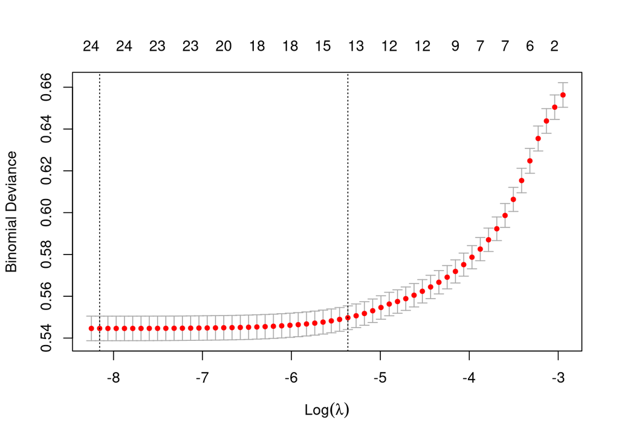

```r
#find the best lambda using cross-validation
set.seed(100)
cv.lasso <- cv.glmnet(X, y, alpha = 1, family = "binomial")
plot(cv.lasso)
```

```r
#optimal lambda
cv.lasso$lambda.min
```

```
## [1] 0.0002869997
```

```r
#lambda with simplest model within one SE of optimal lambda
cv.lasso$lambda.1se
```

```
## [1] 0.00467738
```

Fit logistic regression model with lasso penalty **(using optimal lambda)**.

- The dummy variables for Other ethnicity and widowed are set to zero (i.e. removed from the model). Since it is generally best practice to keep all levels of a categorical variable, we would **not** remove these dummy variables from our final model.

```r
#fit model
lasso.fit <- glmnet(X, y, alpha = 1, family = "binomial",
                lambda = cv.lasso$lambda.min)

#print coefficient estimates and odds ratio
cbind.data.frame(Variable = c("(Intercept)", colnames(X)),
            Estimate = round(as.vector(coef(lasso.fit)), 3),
            OR = round(as.vector(exp(coef(lasso.fit))), 3))
```

```
##                                  Variable Estimate       OR
## 1                             (Intercept)    7.799 2437.406
## 2  ethnicityAMERICAN INDIAN/ALASKA NATIVE   -0.041    0.959
## 3                          ethnicityASIAN    0.181    1.198
## 4         ethnicityBLACK/AFRICAN AMERICAN   -0.155    0.857
## 5                ethnicityHISPANIC/LATINO   -0.093    0.911
## 6                          ethnicityOTHER    0.000    1.000
## 7                        ethnicityUNKNOWN    0.891    2.437
## 8                                 genderM   -0.059    0.942
## 9                                 married   -0.021    0.979
## 10                                 single    0.031    1.032
## 11                                widowed    0.000    1.000
## 12                            bicarbonate   -0.113    0.894
## 13                                calcium   -0.242    0.785
## 14                               chloride   -0.091    0.913
## 15                             creatinine    0.153    1.166
## 16                                glucose    0.004    1.004
## 17                              magnesium    0.143    1.154
## 18                              potassium    0.084    1.087
## 19                                 sodium    0.087    1.091
## 20                             hematocrit   -0.002    0.998
## 21                                    wbc    0.041    1.042
## 22                             heart_rate    0.010    1.010
## 23   non_invasive_blood_pressure_systolic   -0.008    0.993
## 24       non_invasive_blood_pressure_mean    0.002    1.002
## 25                       respiratory_rate    0.043    1.044
## 26                 temperature_fahrenheit   -0.134    0.875
## 27                             age_at_adm    0.032    1.032
```

Fit logistic regression model with lasso penalty **(using lambda that gives simpler model)**.

- The dummy variables for every ethnicity accept Unknown are set to zero. We would keep ethnicity in the final model since one level is still considered significant.
- The dummy variables for all marital status variables are set to zero. We would remove marital status from the final model.
- Gender, hematocrit, and mean NI blood pressure are all set to zero and would be removed from the final model.

```r
#fit model
lasso.fit.simp <- glmnet(X, y, alpha = 1, family = "binomial",
                lambda = cv.lasso$lambda.1se)

#print coefficient estimates and odds ratio
cbind.data.frame(Variable = c("(Intercept)", colnames(X)),
            Estimate = round(as.vector(coef(lasso.fit.simp)), 3),
            OR = round(as.vector(exp(coef(lasso.fit.simp))), 3))
```

```
##                                  Variable Estimate      OR
## 1                             (Intercept)    4.923 137.388
## 2  ethnicityAMERICAN INDIAN/ALASKA NATIVE    0.000   1.000
## 3                          ethnicityASIAN    0.000   1.000
## 4         ethnicityBLACK/AFRICAN AMERICAN    0.000   1.000
## 5                ethnicityHISPANIC/LATINO    0.000   1.000
## 6                          ethnicityOTHER    0.000   1.000
## 7                        ethnicityUNKNOWN    0.786   2.194
## 8                                 genderM    0.000   1.000
## 9                                 married    0.000   1.000
## 10                                 single    0.000   1.000
## 11                                widowed    0.000   1.000
## 12                            bicarbonate   -0.091   0.913
## 13                                calcium   -0.116   0.891
## 14                               chloride   -0.047   0.954
## 15                             creatinine    0.180   1.198
## 16                                glucose    0.003   1.003
## 17                              magnesium    0.003   1.003
## 18                              potassium    0.007   1.007
## 19                                 sodium    0.031   1.032
## 20                             hematocrit    0.000   1.000
## 21                                    wbc    0.039   1.039
## 22                             heart_rate    0.008   1.008
## 23   non_invasive_blood_pressure_systolic   -0.004   0.996
## 24       non_invasive_blood_pressure_mean    0.000   1.000
## 25                       respiratory_rate    0.041   1.042
## 26                 temperature_fahrenheit   -0.079   0.924
## 27                             age_at_adm    0.027   1.027
```

3. Compare model prediction performance on the test set.

#### Solution - compare model prediction performance

##### Logistic regression

The model’s prediction accuracy is 90.17%

```r
#make predictions on test data
probabilities.logit <- logit.fit %>% predict(test, type = "response")
predicted.death.logit <- ifelse(probabilities.logit > 0.5, 1, 0)

#model accuracy
observed.death <- test$died_in_30days
mean(predicted.death.logit == observed.death)
```

```
## [1] 0.9016885
```

##### Logistic regression with lasso penalty

Using the optimal lambda, the model’s prediction accuracy is 90.06%

```r
#make predictions on test data
x.test <- model.matrix(died_in_30days ~ ., test)[, -c(1, 2)]
probabilities.lasso <- lasso.fit %>% predict(newx = x.test)
predicted.death.lasso <- ifelse(probabilities.lasso > 0.5, 1, 0)

#model accuracy
mean(predicted.death.lasso == observed.death)
```

```
## [1] 0.9005895
```

Using the lambda that gives the simpler model, the model’s prediction accuracy is 89.94%

```r
#make predictions on test data
probabilities.lasso.simp <- lasso.fit.simp %>% predict(newx = x.test)
predicted.death.lasso.simp <- ifelse(probabilities.lasso.simp > 0.5, 1, 0)

#model accuracy
mean(predicted.death.lasso.simp == observed.death)
```

```
## [1] 0.8993905
```

##### Prediction results

The prediction accuracy of each model are all within 0.23% of each other. Since, the prediction performance of each model is so similar, we will choose the simplest model as our final model. Therefore we will remove marital status, gender, hematocrit, and mean NI blood pressure from the model.

#### Results of final model

Using the full ICU cohort data set with imputed values, the following **significant** relationships between a given variable (controlling for all other variables in the model) and occurrence of death within 30 days of ICU admission were seen.

- The odds of a patient of unknown ethnicity dying within 30 days compared to a White patient are 2.48.
- For every one year increase in age and every one unit increase in creatinine, glucose, magnesium, potassium, sodium, wbc, heart rate, and respiratory rate patients had higher odds of dying in 30 days.
- For every one unit increase in bicarbonate, calcium, chloride, systolic NI blood pressure, and temperature patients had lower odds of dying in 30 days.

```r
#set white to be the reference group for ethnicity
icu_cohort_imp$ethnicity <- relevel(as.factor(icu_cohort_imp$ethnicity),
                                    "WHITE")

#fit logistic regression model
final.fit <- glm(died_in_30days ~ ethnicity + age_at_adm + bicarbonate +
                   calcium + chloride + creatinine + glucose + magnesium +
                   potassium + sodium + wbc + heart_rate +
                   non_invasive_blood_pressure_systolic +
                   respiratory_rate + temperature_fahrenheit,
                 data = icu_cohort_imp,
                 family = binomial)

#print odds ratios and their confidence intervals
round(exp(cbind(OR = coef(final.fit), confint(final.fit))), 2)
```

```
##                                              OR  2.5 %    97.5 %
## (Intercept)                            12698.62 519.49 310910.59
## ethnicityAMERICAN INDIAN/ALASKA NATIVE     0.72   0.27      1.59
## ethnicityASIAN                             1.15   0.96      1.38
## ethnicityBLACK/AFRICAN AMERICAN            0.90   0.80      1.02
## ethnicityHISPANIC/LATINO                   0.90   0.73      1.10
## ethnicityOTHER                             1.04   0.89      1.22
## ethnicityUNKNOWN                           2.48   2.28      2.69
## age_at_adm                                 1.03   1.03      1.03
## bicarbonate                                0.89   0.88      0.90
## calcium                                    0.78   0.74      0.82
## chloride                                   0.91   0.90      0.92
## creatinine                                 1.15   1.12      1.19
## glucose                                    1.00   1.00      1.00
## magnesium                                  1.17   1.07      1.28
## potassium                                  1.11   1.05      1.16
## sodium                                     1.09   1.08      1.11
## wbc                                        1.04   1.04      1.05
## heart_rate                                 1.01   1.01      1.01
## non_invasive_blood_pressure_systolic       0.99   0.99      1.00
## respiratory_rate                           1.04   1.04      1.05
## temperature_fahrenheit                     0.86   0.83      0.89
```